# 项目背景及目的

Prosper是美国的一家P2P在线借贷平台网站。网站撮合了一些有闲钱的人和一些急于用钱的人。用户若有贷款需求，可在网站上列出期望数额和可承受的最大利率。潜在贷方则为数额和利率展开竞价。卖家可以获得比银行更高的利息收入，而对于买家来说，除了过程快捷便利和可以获得较低的还款利率外，更主要的是你不需要经过漫长的审查过程，不会遇到在银行申请贷款遭拒时的尴尬。本案例试图从EDA分析角度出发，分析Propser数据集中贷款人条件及贷款利率等问题。

### 单变量绘图选择

```
## [1] 36 60 12
```

```
##
##           A    AA     B     C     D     E    HR
## 29084 14551  5372 15581 18345 14274  9795  6935
```

```
##
##                    Employed     Full-time Not available  Not employed
##          2255         67322         26355          5347           835
##         Other     Part-time       Retired Self-employed
##          3806          1088           795          6134
```

```
##
##     0     1     2     3     4     5     6     7     8     9    10    11
## 16965 58308  7433  7189  2395   756  2572 10494   199    85    91   217
##    12    13    14    15    16    17    18    19    20
##    59  1996   876  1522   304    52   885   768   771
```

#### 贷款期限

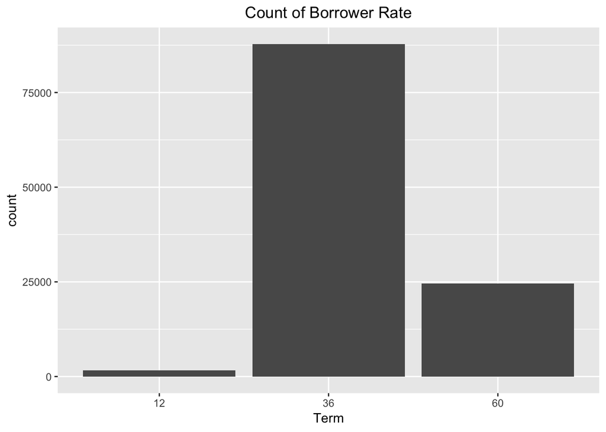

观察图我们可以发现，大部分贷款年限为3年

#### 贷款利率

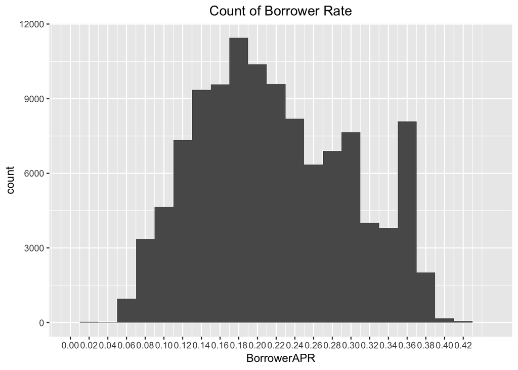

#### 贷方收益率

```
##    Min. 1st Qu.  Median    Mean 3rd Qu.    Max.
## -0.0100  0.1242  0.1730  0.1827  0.2400  0.4925
```

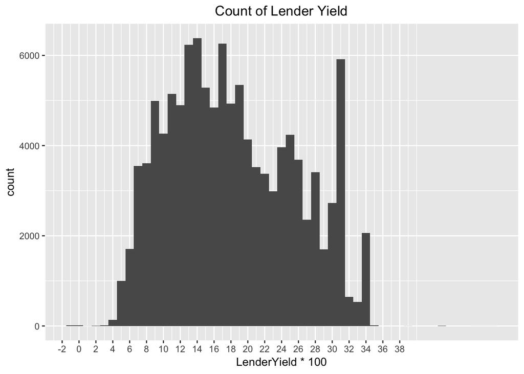

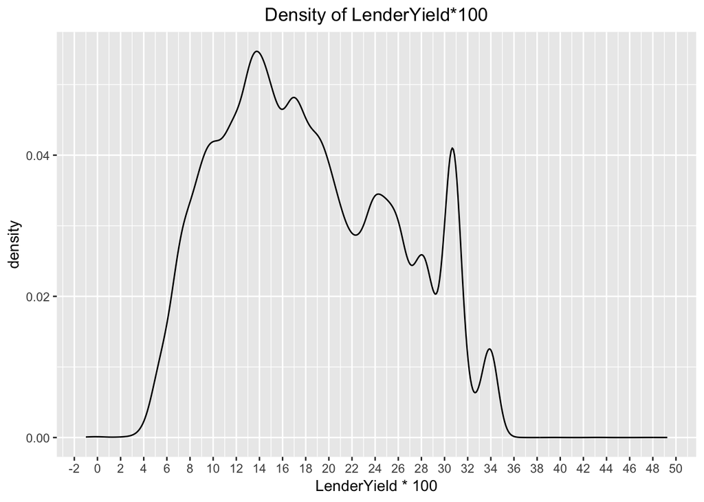

我们用lenderyield乘100来看收益率百分比数，贷款人收益在15%左右，有正态分布的趋势，大部分收益利率相对于银行传统储蓄率较高。而且有负利率的情况出现，需要得到投资人的注意。

#### 借款人就业情况

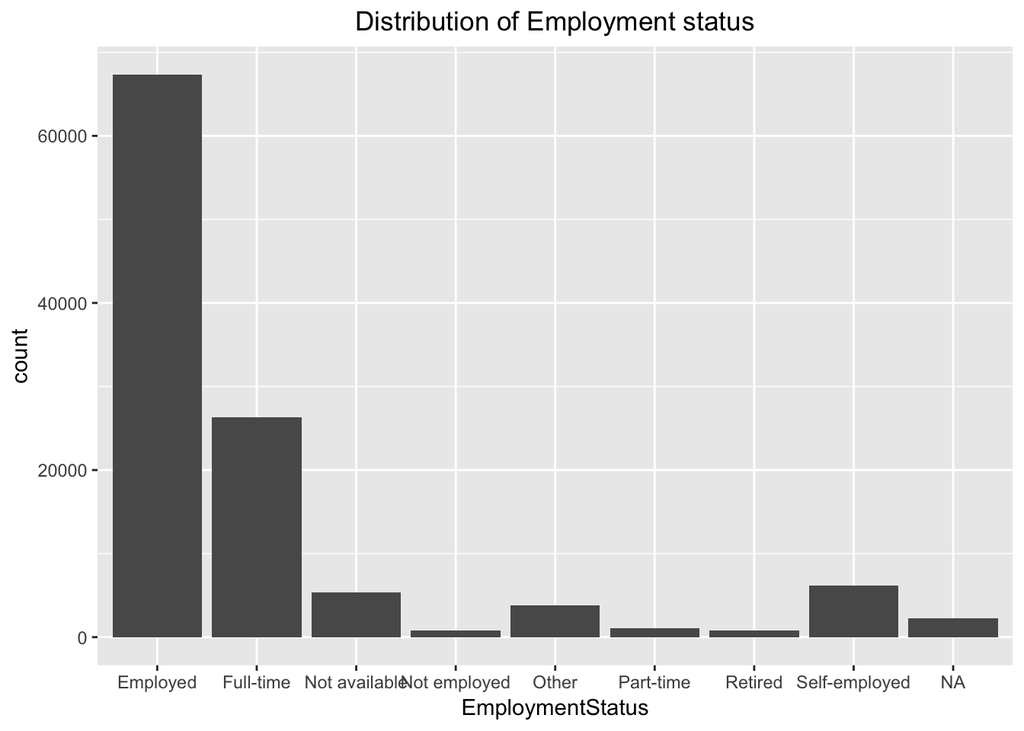

我们可以看到，大部分申请贷款的人员都属于在职员工。

#### 对借款人的评级

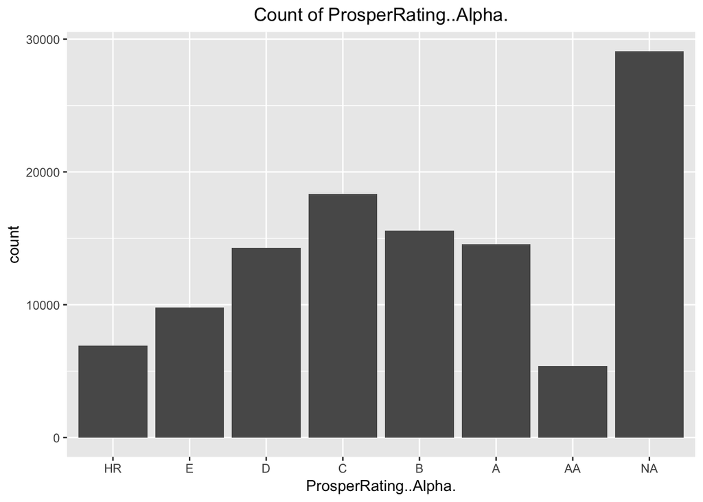

我们看数据分布大致呈现正态分布， 信用评级为C的人比较多。

#### 借款人所在地

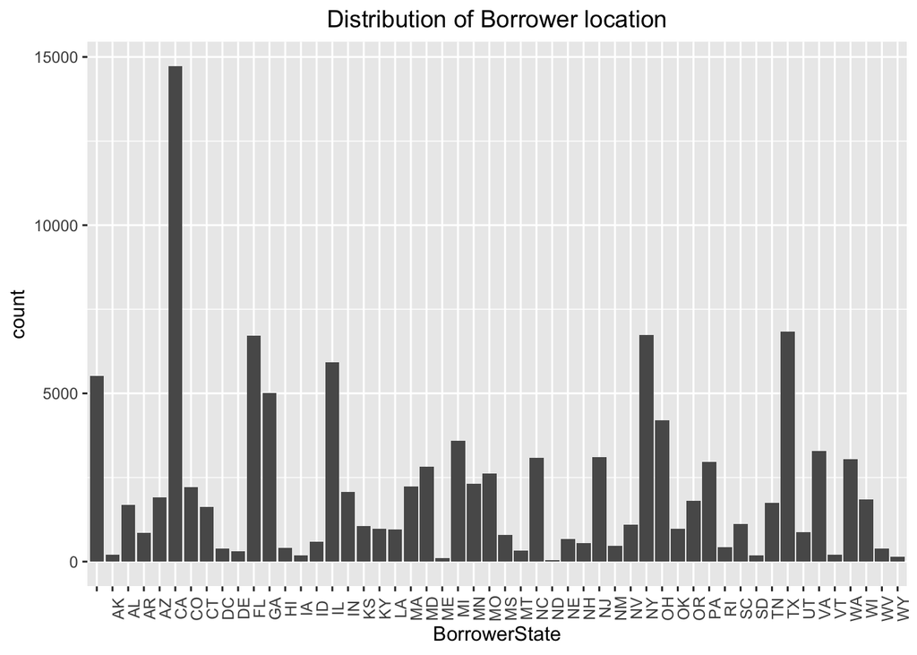

我们看到加州的贷款人数量最多。

#### 借款人收入范围

```
##
##            $0        $1-24k      $25k-49k      $50k-75k     $75k-100k
##           621          7274         32192         31050         16916
##        $100k+ Not displayed  Not employed
##         17337          7741           806
```

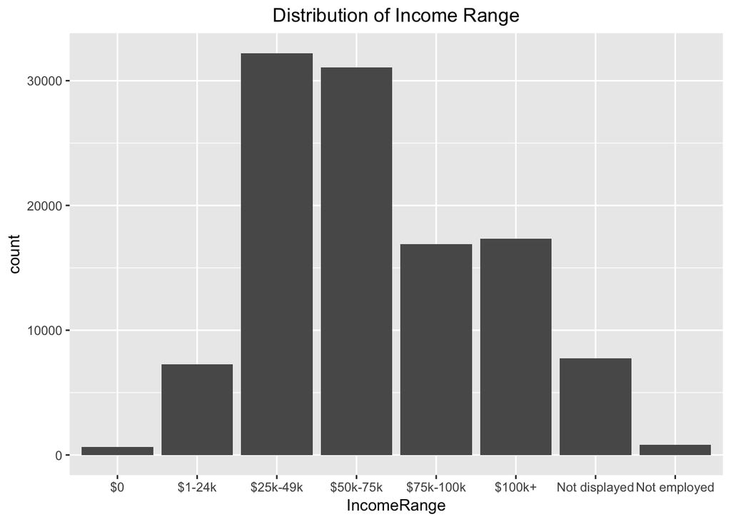

我们可以看到大部分借款人收入在25000-75000之间， 其次高收入人群的比例很高。

#### 贷款的类别

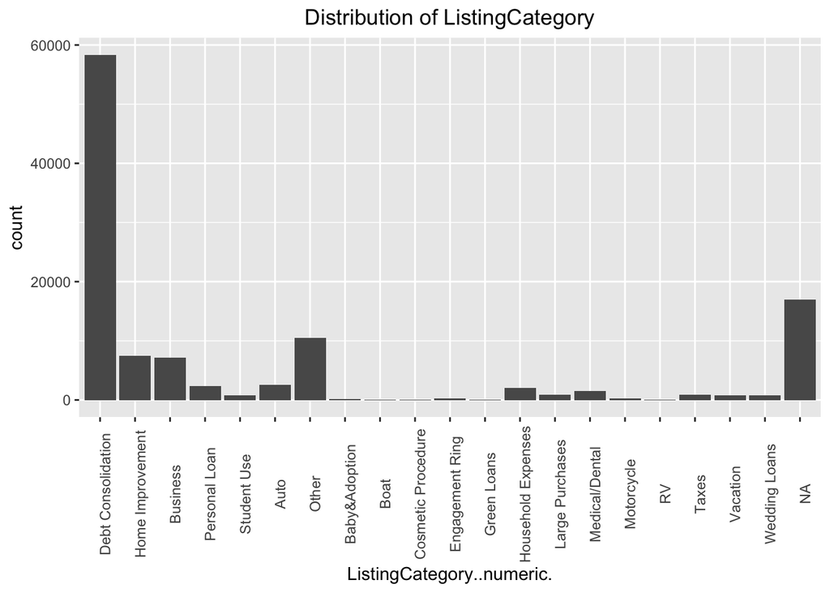

可以看到因为债务合并而贷款的最多，其次是其他，家庭和商业原因也是比较多的理由。

# 单变量分析

### 你的数据集结构是什么？

```
在单变量分析的过程中，我选用了8个变量。Term, BorrowerAPR, LenderYield, EmploymentStatus, IncomeRange, ListingCategory..numeric., BorrowerState, ProsperRating..Alpha.
```

### 你的数据集内感兴趣的主要特性有哪些？

```
选取的变量主要研究了贷款人的基本工作以及财务，信用情况， 贷款年限，利率及收益，用途。
收益率和贷款利率可以作为衡量贷款好坏的一个重要标准
```

### 你认为数据集内哪些其他特征可以帮助你探索兴趣特点？

```
“DelinquenciesLast7Years”过去7年违约次数、“StatedMonthlyIncome”借款人月收入可以帮助我探索、“Investors贷款投资人数”可以帮助我探索。没有创建新变量
```

### 根据数据集内已有变量，你是否创建了任何新变量？

```
没有创建新变量。
```

### 在已经探究的特性中，是否存在任何异常分布？你是否对数据进行一些操作，如清洁、调整或改变数据的形式？如果是，你为什么会这样做？

```
变量的缺失值比较多。
因为贷款期限数据只有3种情况，将数据类型改为Factor
对借款人的评级，对缺失的数据标记了NA
借款人的是否被雇佣情况也对缺失数据标注了NA
把借款用途的数字标记改为文字，在可视化时得到了更好的效果
```

# 双变量绘图选择

#### 贷款利率,收益与期限的关系

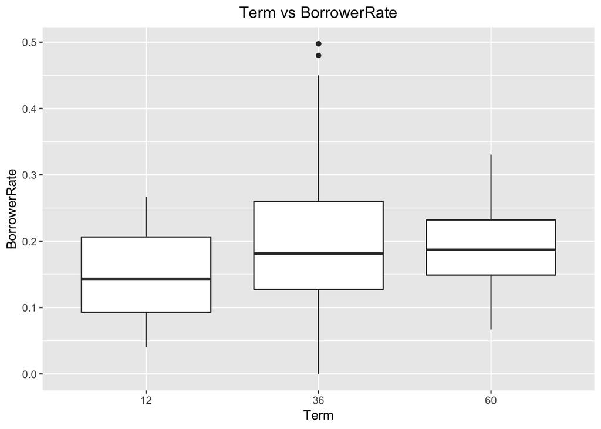

```
## load_data$Term: 12
##    Min. 1st Qu.  Median    Mean 3rd Qu.    Max.
##  0.0400  0.0929  0.1434  0.1501  0.2064  0.2669
## --------------------------------------------------------
## load_data$Term: 36
##    Min. 1st Qu.  Median    Mean 3rd Qu.    Max.
##  0.0000  0.1274  0.1815  0.1935  0.2599  0.4975
## --------------------------------------------------------
## load_data$Term: 60
##    Min. 1st Qu.  Median    Mean 3rd Qu.    Max.
##  0.0669  0.1490  0.1870  0.1930  0.2319  0.3304
```

我们可以看到，12个月的贷款利率相对于3年5年的利率相对偏小，但3年和5年的利率界限不明显。

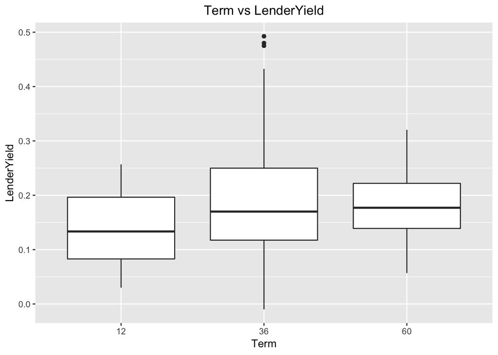

```
## load_data$Term: 12
##    Min. 1st Qu.  Median    Mean 3rd Qu.    Max.
##  0.0300  0.0829  0.1334  0.1401  0.1964  0.2569
## --------------------------------------------------------
## load_data$Term: 36
##    Min. 1st Qu.  Median    Mean 3rd Qu.    Max.
## -0.0100  0.1174  0.1700  0.1834  0.2499  0.4925
## --------------------------------------------------------
## load_data$Term: 60
##    Min. 1st Qu.  Median    Mean 3rd Qu.    Max.
##  0.0569  0.1390  0.1770  0.1830  0.2219  0.3204
```

同样，12个月的收益相对于3年5年的收益相对偏小，但3年和5年的界限不明显。

#### 贷款利率，收益与收入的关系

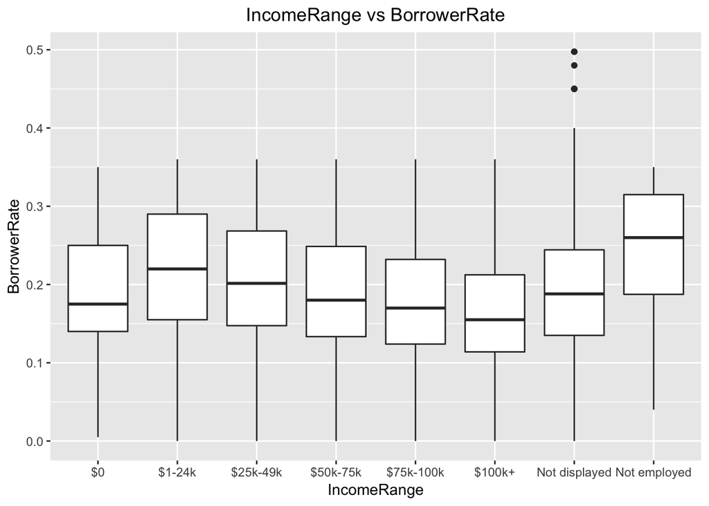

```
## load_data$IncomeRange: $0
##    Min. 1st Qu.  Median    Mean 3rd Qu.    Max.
##  0.0050  0.1400  0.1750  0.1952  0.2500  0.3500
## --------------------------------------------------------
## load_data$IncomeRange: $1-24k
##    Min. 1st Qu.  Median    Mean 3rd Qu.    Max.
##  0.0000  0.1550  0.2199  0.2206  0.2900  0.3600
## --------------------------------------------------------
## load_data$IncomeRange: $25k-49k
##    Min. 1st Qu.  Median    Mean 3rd Qu.    Max.
##  0.0000  0.1474  0.2015  0.2072  0.2684  0.3600
## --------------------------------------------------------
## load_data$IncomeRange: $50k-75k
##    Min. 1st Qu.  Median    Mean 3rd Qu.    Max.
##  0.0000  0.1334  0.1800  0.1903  0.2487  0.3600
## --------------------------------------------------------
## load_data$IncomeRange: $75k-100k
##    Min. 1st Qu.  Median    Mean 3rd Qu.    Max.
##  0.0000  0.1239  0.1699  0.1809  0.2321  0.3600
## --------------------------------------------------------
## load_data$IncomeRange: $100k+
##    Min. 1st Qu.  Median    Mean 3rd Qu.    Max.
##  0.0000  0.1139  0.1550  0.1692  0.2124  0.3600
## --------------------------------------------------------
## load_data$IncomeRange: Not displayed
##    Min. 1st Qu.  Median    Mean 3rd Qu.    Max.
##  0.0000  0.1350  0.1880  0.1892  0.2443  0.4975
## --------------------------------------------------------
## load_data$IncomeRange: Not employed
##    Min. 1st Qu.  Median    Mean 3rd Qu.    Max.
##  0.0400  0.1874  0.2600  0.2467  0.3149  0.3500
```

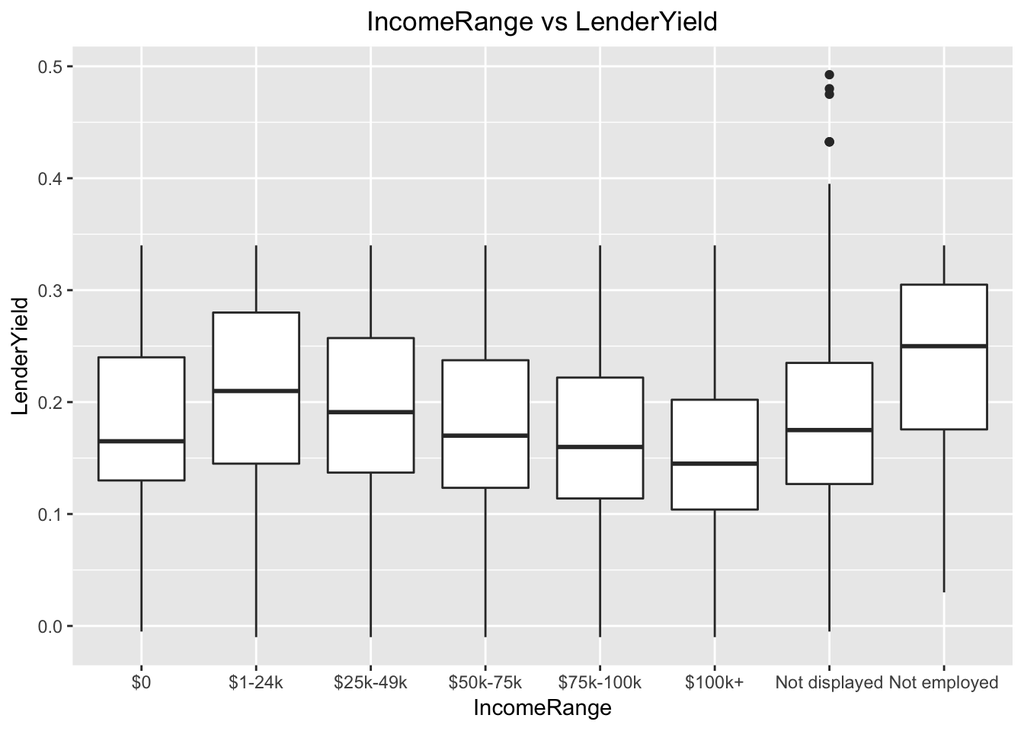

```
## load_data$IncomeRange: $0
##    Min. 1st Qu.  Median    Mean 3rd Qu.    Max.
## -0.0050  0.1300  0.1650  0.1857  0.2400  0.3400
## --------------------------------------------------------
## load_data$IncomeRange: $1-24k
##    Min. 1st Qu.  Median    Mean 3rd Qu.    Max.
## -0.0100  0.1450  0.2099  0.2101  0.2800  0.3400
## --------------------------------------------------------
## load_data$IncomeRange: $25k-49k
##    Min. 1st Qu.  Median    Mean 3rd Qu.    Max.
## -0.0100  0.1370  0.1910  0.1969  0.2572  0.3400
## --------------------------------------------------------
## load_data$IncomeRange: $50k-75k
##    Min. 1st Qu.  Median    Mean 3rd Qu.    Max.
## -0.0100  0.1234  0.1700  0.1803  0.2374  0.3400
## --------------------------------------------------------
## load_data$IncomeRange: $75k-100k
##    Min. 1st Qu.  Median    Mean 3rd Qu.    Max.
## -0.0100  0.1139  0.1599  0.1709  0.2219  0.3400
## --------------------------------------------------------
## load_data$IncomeRange: $100k+
##    Min. 1st Qu.  Median    Mean 3rd Qu.    Max.
## -0.0100  0.1040  0.1450  0.1593  0.2021  0.3400
## --------------------------------------------------------
## load_data$IncomeRange: Not displayed
##    Min. 1st Qu.  Median    Mean 3rd Qu.    Max.
## -0.0050  0.1268  0.1750  0.1799  0.2350  0.4925
## --------------------------------------------------------
## load_data$IncomeRange: Not employed
##    Min. 1st Qu.  Median    Mean 3rd Qu.    Max.
##  0.0300  0.1756  0.2500  0.2365  0.3049  0.3400
```

我们可以看到，随着收入的增加， 他们的收益率是在不断降低的。

#### 贷款利率，收益与借款人评级的关系

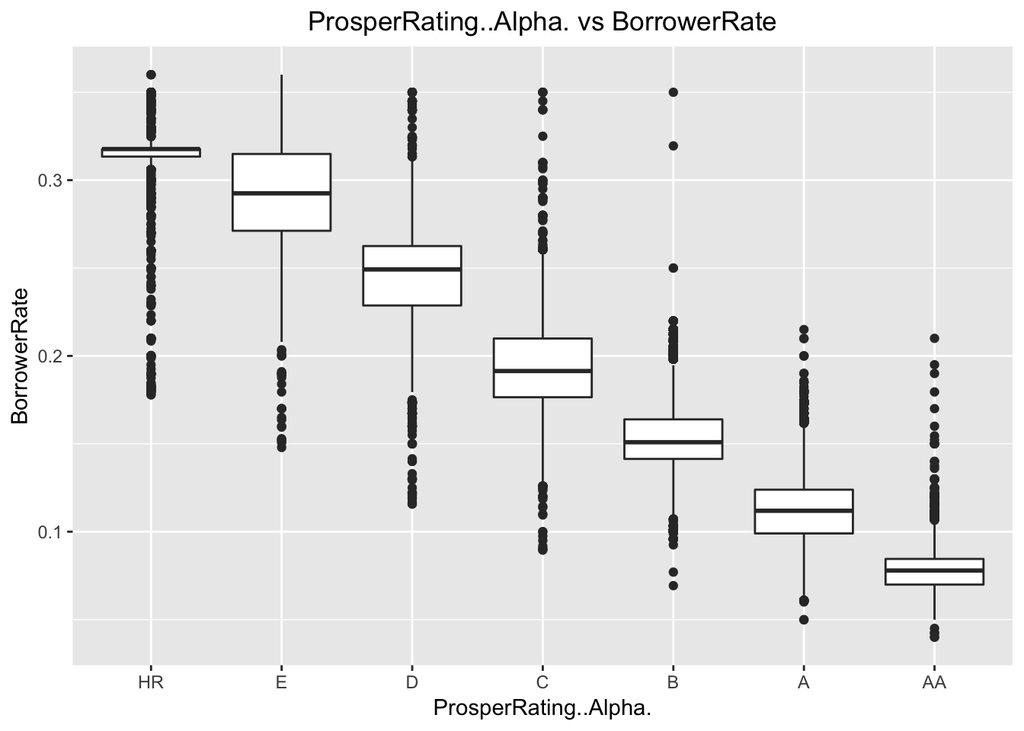

```
## load_data$ProsperRating..Alpha.: HR
##    Min. 1st Qu.  Median    Mean 3rd Qu.    Max.
##  0.1779  0.3134  0.3177  0.3173  0.3177  0.3600
## --------------------------------------------------------
## load_data$ProsperRating..Alpha.: E
##    Min. 1st Qu.  Median    Mean 3rd Qu.    Max.
##  0.1479  0.2712  0.2925  0.2933  0.3149  0.3600
## --------------------------------------------------------
## load_data$ProsperRating..Alpha.: D
##    Min. 1st Qu.  Median    Mean 3rd Qu.    Max.
##  0.1157  0.2287  0.2492  0.2464  0.2625  0.3500
## --------------------------------------------------------
## load_data$ProsperRating..Alpha.: C
##    Min. 1st Qu.  Median    Mean 3rd Qu.    Max.
##  0.0895  0.1765  0.1914  0.1944  0.2099  0.3500
## --------------------------------------------------------
## load_data$ProsperRating..Alpha.: B
##    Min. 1st Qu.  Median    Mean 3rd Qu.    Max.
##  0.0693  0.1414  0.1509  0.1545  0.1639  0.3500
## --------------------------------------------------------
## load_data$ProsperRating..Alpha.: A
##    Min. 1st Qu.  Median    Mean 3rd Qu.    Max.
##  0.0498  0.0990  0.1119  0.1129  0.1239  0.2150
## --------------------------------------------------------
## load_data$ProsperRating..Alpha.: AA
##    Min. 1st Qu.  Median    Mean 3rd Qu.    Max.
## 0.04000 0.06990 0.07790 0.07912 0.08450 0.21000
```

我们可以看到明显的趋势，信用等级越高的人，贷款利率相对越低。

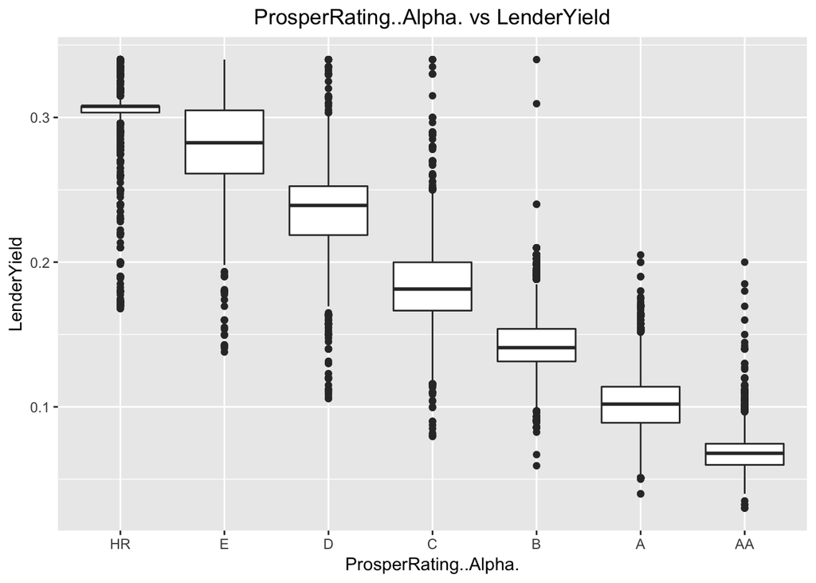

```
## load_data$ProsperRating..Alpha.: HR
##    Min. 1st Qu.  Median    Mean 3rd Qu.    Max.
##  0.1679  0.3034  0.3077  0.3073  0.3077  0.3400
## --------------------------------------------------------
## load_data$ProsperRating..Alpha.: E
##    Min. 1st Qu.  Median    Mean 3rd Qu.    Max.
##  0.1379  0.2612  0.2825  0.2833  0.3049  0.3400
## --------------------------------------------------------
## load_data$ProsperRating..Alpha.: D
##    Min. 1st Qu.  Median    Mean 3rd Qu.    Max.
##  0.1057  0.2187  0.2392  0.2364  0.2525  0.3400
## --------------------------------------------------------
## load_data$ProsperRating..Alpha.: C
##    Min. 1st Qu.  Median    Mean 3rd Qu.    Max.
##  0.0795  0.1665  0.1814  0.1844  0.1999  0.3400
## --------------------------------------------------------
## load_data$ProsperRating..Alpha.: B
##    Min. 1st Qu.  Median    Mean 3rd Qu.    Max.
##  0.0593  0.1314  0.1409  0.1444  0.1539  0.3400
## --------------------------------------------------------
## load_data$ProsperRating..Alpha.: A
##    Min. 1st Qu.  Median    Mean 3rd Qu.    Max.
##  0.0398  0.0890  0.1019  0.1029  0.1139  0.2050
## --------------------------------------------------------
## load_data$ProsperRating..Alpha.: AA
##    Min. 1st Qu.  Median    Mean 3rd Qu.    Max.
## 0.03000 0.05990 0.06790 0.06911 0.07450 0.20000
```

我们再一次发现，通过和收益与收入的关系对比，收益率也是随着信用等级的增加而降低。

#### 贷款利率与收益的关系

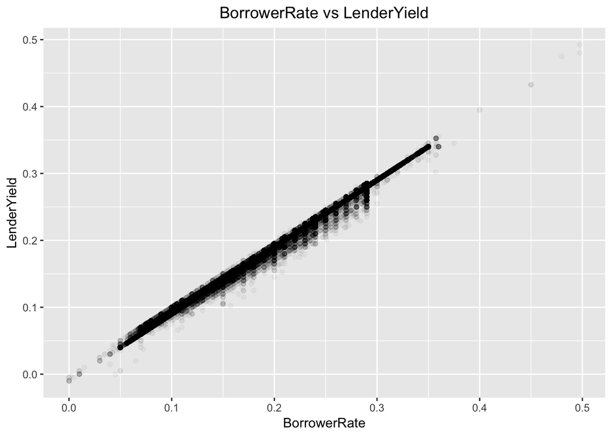

```
##
##  Pearson's product-moment correlation
##
## data:  load_data$BorrowerRate and load_data$LenderYield
## t = 8493.9, df = 113940, p-value < 2.2e-16
## alternative hypothesis: true correlation is not equal to 0
## 95 percent confidence interval:
##  0.9992021 0.9992204
## sample estimates:
##       cor
## 0.9992113
```

我们可以看到这二者有很强的相关性，贷款利率越高，收益越大

# 双变量分析

### 探讨你在这部分探究中观察到的一些关系。这些感兴趣的特性与数据集内其他特性有什么区别？

```
贷款的期限在一年的借款利率 和收益率都相对较低， 但是3年期限与5年期限的贷款 收益，借款利率差异不大。
随着收入水平的增加以及信用评级的提高， 收益利率反而在逐渐变小。
```

### 你是否观察到主要特性与其他特性之间的有趣关系？

```
在分析中发现，随着收入水平的增加以及信用评级的提高，收益利率反而在逐渐变小。和我的认知不同。
```

### 你发现最强的关系是什么？

```
贷款的收益 和 借款的利率呈现了极强的相关性。
```

# 多变量绘图选择

#### LoanOriginalAmount与DelinquenciesLast7Years、ProsperRating..Alpha.之间的关系

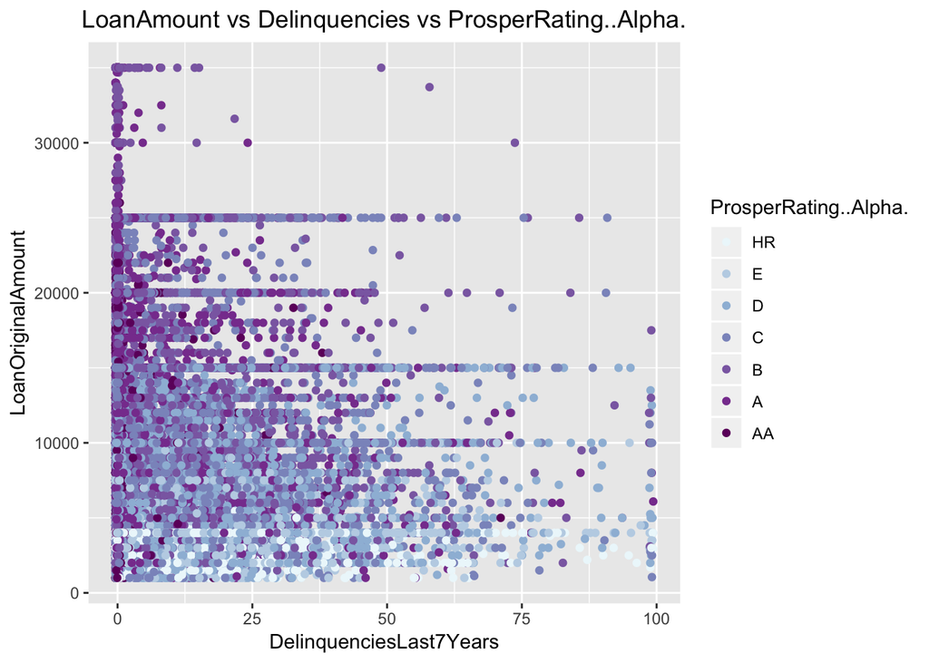

我们可以看到大致的趋势，信用好的，欠款及时还，贷款的金额也相对大。从左上区域到右下区域，分布的点的颜色逐渐变浅

##LenderYield与ProsperRating..Alpha.、IncomeRange的关系

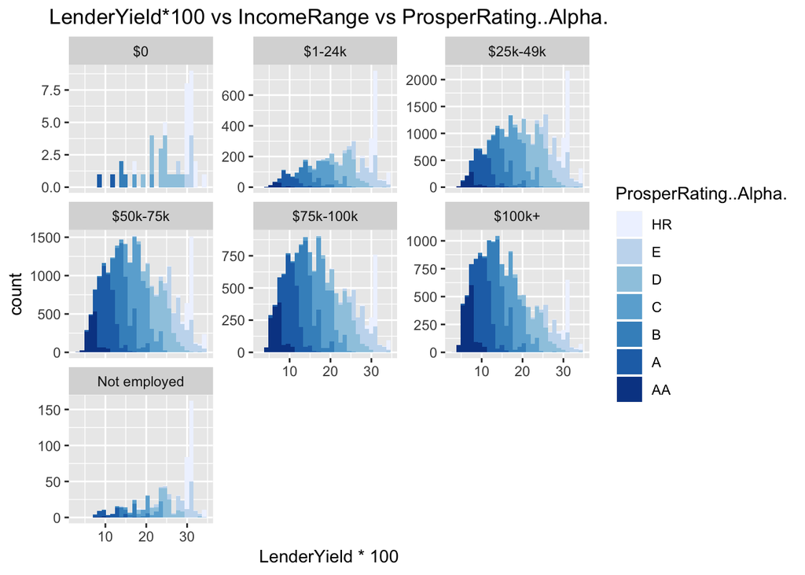

在同一图内对比， 我们可以看到随着信用评级的增强，收益率明显出现降低。 多图对比，随着收入的增加我们发现数据分布呈现了正偏的情况，深色的数据比例在增大。 信用情况和收入情况正相关关系， 信用，收入与收益率有负相关关系。

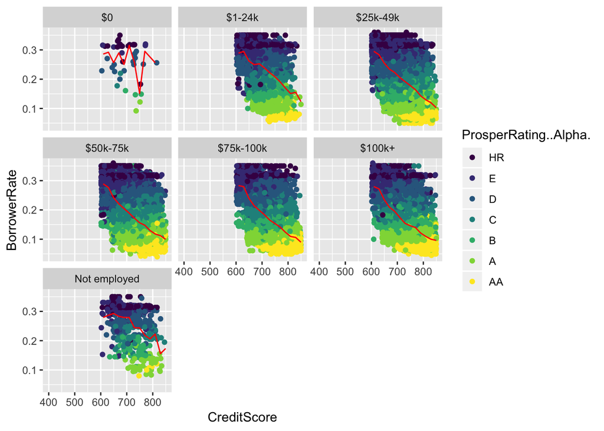

贷款利率随着评级，信用分升高而下降，与收入的关系不大。

# 多变量分析

### 探讨你在这部分探究中观察到的一些关系。通过观察感兴趣的特性，是否存在相互促进的特性？

```
  信用良好的人，欠款不还违约的次数少，相对更容易拿到大额的贷款。
  随着信用评级的增强，收益率明显出现降低。
  随着收入的增加我们发现数据分布呈现了正偏的情况，信用评级良好的人的比例也在增加，但是同样 收益率在降低。
  贷款利率随着评级，信用分升高而下降。
```

### 这些特性之间是否存在有趣或惊人的联系呢？

[output not shown]

### 选项：你是否创建过数据集的任何模型？讨论你模型的优缺点。

# 定稿图与总结

### 绘图一

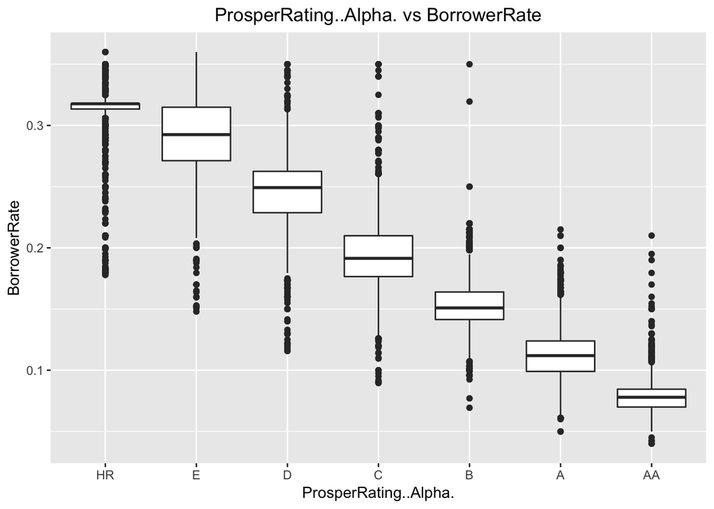

### 描述一

我们可以看到明显的趋势，信用等级越高的人，贷款利率相对越低。

### 绘图二

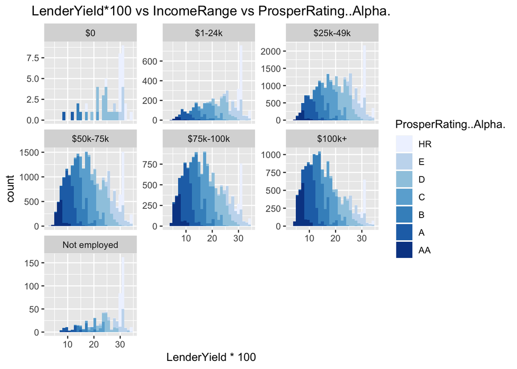

### 描述二

在同一图内对比， 我们可以看到随着信用评级的增强，收益率明显出现降低。 多图对比，随着收入的增加我们发现数据分布呈现了正偏的情况，深色的数据比例在增大。 信用情况和收入情况正相关关系， 信用，收入与收益率有负相关关系

### 绘图三

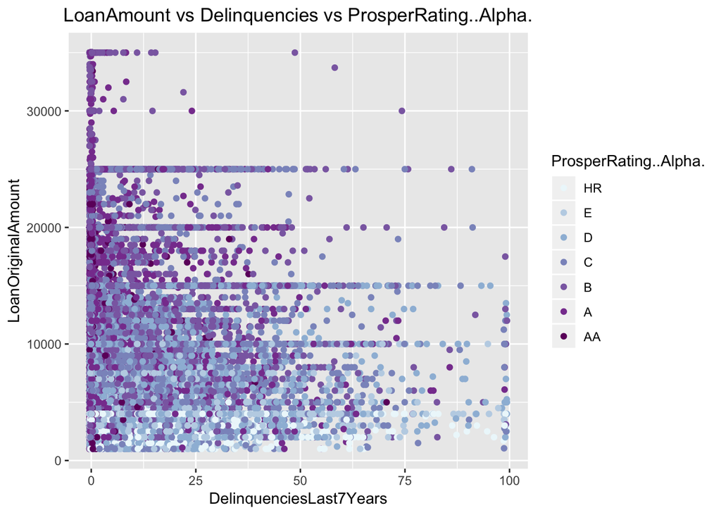

### 描述三

我们可以看到大致的趋势，信用好的，欠款及时还，贷款的金额也相对大。信用等级低且过去违约次数多的人只能贷到数额较低的贷款。 随着DelinquenciesLast7Years的增大，LoanOriginalAmount的值域（最大值）在不断地减少，信用等级也在不断降低。

# 反思

贷款数据集包含了太多数据，而且每项贷款有81个变量。可供选择的变量太多了，并且因为没有接触过相关业务，导致不知道应该选用哪些数据，也未能创建更多的变量，在以后应该多读一些相关领域的报告。通过上网查询以及了解数据集中的各个变量，我研究了一些变量与贷款额,利率,收益，贷款人信用之间的关系。

因为之前使用python多一些，因而对于r语言不是很熟练，遇到了很多问题，在网络检索中花费了不少的时间，但是也收益很多。